# Final Proposal

Roba Abbajabal, Conor O’Shea, Aadhi Subbiah, Daniel Nass

11/11/2023

# Research Title: An Analysis on Transportation Safety

##### Team Members: Roba Abbajabal, Conor O’Shea, Aadhi Subbiah, Daniel Nass

#### Description of Data:

This data set contains information from 2010-2021 regarding fatal vehicular accidents that have occured on highways within the United States by state/territory. The data can be acessed at the following link: https://www.bts.gov/browse-statistical-products-and-data/state-transportation-statistics/transportation-safety The varibles included in this dataset are as follows: - State: the state that the information comes from - Fatality Type: A factor of 14 different types of fatalities (such as highway fatalities, SUV fatalities, etc.) - Year: The year, from 2010 to 2021, of the number of a specific type of fatality in a state occured.

#### Investigation:

What states, if any, have stark contrasts in vehicular fatalities? Do these states have any laws or regulations that would cause this? Have counts of certain types of vehicular fatalities increased or decreased over time? Do any types of vehicular fatalities correlate with another?

```r
# csv being used
hw <- read.csv("hwFatal.csv")
head(hw)
```

```
##           State                            X  X2010  X2011  X2012  X2013  X2014
## 1 United States           Highway Fatalities 32,999 32,479 33,782 32,893 32,744
## 2 United States     Passenger Car Fatalities 12,491 12,014 12,361 12,037 11,947
## 3 United States               SUV Fatalities  3,942  3,884  3,885  3,831  3,800
## 4 United States      Pickup Truck Fatalities  4,486  4,270  4,343  4,175  4,249
## 5 United States               Van Fatalities  1,346  1,128  1,167  1,142  1,021
## 6 United States Other Light Truck Fatalities      8     20     23     38     33
##    X2015  X2016  X2017  X2018  X2019  X2020  X2021
## 1 35,484 37,806 37,473 36,835 36,355 39,007 42,939
## 2 12,763 13,508 13,477 12,888 12,355 12,628 13,529
## 3  4,213  4,462  4,610  4,554  4,727  6,015  6,961
## 4  4,471  4,470  4,335  4,267  4,213  4,333  4,757
## 5  1,128  1,240  1,175  1,081  1,025    938  1,078
## 6     66    107     66     55     52      0      0
```

```r
# information about data set
summary(hw)
```

```
##     State                X                X2010              X2011
##  Length:742         Length:742         Length:742         Length:742
##  Class :character   Class :character   Class :character   Class :character
##  Mode  :character   Mode  :character   Mode  :character   Mode  :character
##     X2012              X2013              X2014              X2015
##  Length:742         Length:742         Length:742         Length:742
##  Class :character   Class :character   Class :character   Class :character
##  Mode  :character   Mode  :character   Mode  :character   Mode  :character
##     X2016              X2017              X2018              X2019
##  Length:742         Length:742         Length:742         Length:742
##  Class :character   Class :character   Class :character   Class :character
##  Mode  :character   Mode  :character   Mode  :character   Mode  :character
##     X2020              X2021
##  Length:742         Length:742
##  Class :character   Class :character
##  Mode  :character   Mode  :character
```

```r
# Cleaning data

## Fixing empty column name for Fatality Type, and making year column names start with a character
hw <-  read.csv("hwFatal.csv", col.names = c("State","FatalityType","Y2010","Y2011","Y2012","Y2013","Y2014","Y2015","Y2016","Y2017","Y2018","Y2019","Y2020","Y2021"))

## Creating a seocnd dataset where there the whole country collectively is not included (just states and territories individually)
states <- hw %>% filter(State != "United States")
states$State <- tolower(states$State) # making joining with the map easier later on
head(states)
```

```
##     State                 FatalityType Y2010 Y2011 Y2012 Y2013 Y2014 Y2015
## 1 alabama           Highway Fatalities   862   895   865   853   820   850
## 2 alabama     Passenger Car Fatalities   376   389   370   357   337   355
## 3 alabama               SUV Fatalities   125   112   112   137   116   111
## 4 alabama      Pickup Truck Fatalities   153   154   140   151   150   156
## 5 alabama               Van Fatalities    33    27    26    20    15    23
## 6 alabama Other Light Truck Fatalities     2     1     0     1     0     3
##   Y2016 Y2017 Y2018 Y2019 Y2020 Y2021
## 1 1,083   948   953   930   934   983
## 2   416   395   411   362   371   368
## 3   166   143   136   126   166   182
## 4   165   145   149   160   152   131
## 5    24    27    19    21    16    40
## 6     9     1     1     4     0     0
```

```r
## Parse the fatality by year as a number, and not a character.
states <- states %>%
    mutate (
        Y2010 = parse_number(Y2010),
        Y2011 = parse_number(Y2011),
        Y2012 = parse_number(Y2012),
        Y2013 = parse_number(Y2013),
        Y2014 = parse_number(Y2014),
        Y2015 = parse_number(Y2015),
        Y2016 = parse_number(Y2016),
        Y2017 = parse_number(Y2017),
        Y2018 = parse_number(Y2018),
        Y2019 = parse_number(Y2019),
        Y2020 = parse_number(Y2020),
        Y2021 = parse_number(Y2021),
    )

# information about data set
summary(states)
```

```
##     State           FatalityType           Y2010             Y2011
##  Length:728         Length:728         Min.   :   0.00   Min.   :   0.00
##  Class :character   Class :character   1st Qu.:   1.00   1st Qu.:   1.00
##  Mode  :character   Mode  :character   Median :  13.00   Median :  13.00
##                                        Mean   :  91.61   Mean   :  90.23
##                                        3rd Qu.:  70.00   3rd Qu.:  70.25
##                                        Max.   :3023.00   Max.   :3054.00
##      Y2012             Y2013             Y2014             Y2015
##  Min.   :   0.00   Min.   :   0.00   Min.   :   0.00   Min.   :   0.00
##  1st Qu.:   1.00   1st Qu.:   1.00   1st Qu.:   1.00   1st Qu.:   1.00
##  Median :  13.00   Median :  13.00   Median :  13.00   Median :  13.50
##  Mean   :  93.83   Mean   :  91.34   Mean   :  90.84   Mean   :  98.36
##  3rd Qu.:  75.00   3rd Qu.:  71.50   3rd Qu.:  69.00   3rd Qu.:  75.00
##  Max.   :3408.00   Max.   :3389.00   Max.   :3536.00   Max.   :3582.00
##      Y2016            Y2017             Y2018             Y2019
##  Min.   :   0.0   Min.   :   0.00   Min.   :   0.00   Min.   :   0.0
##  1st Qu.:   2.0   1st Qu.:   2.00   1st Qu.:   1.75   1st Qu.:   2.0
##  Median :  17.0   Median :  15.00   Median :  15.00   Median :  14.0
##  Mean   : 104.6   Mean   : 103.76   Mean   : 102.02   Mean   : 100.7
##  3rd Qu.:  81.0   3rd Qu.:  79.25   3rd Qu.:  80.50   3rd Qu.:  78.0
##  Max.   :3837.0   Max.   :3884.00   Max.   :3798.00   Max.   :3719.0
##      Y2020            Y2021
##  Min.   :   0.0   Min.   :   0.00
##  1st Qu.:   1.0   1st Qu.:   1.00
##  Median :  16.0   Median :  17.00
##  Mean   : 107.8   Mean   : 118.85
##  3rd Qu.:  79.0   3rd Qu.:  91.25
##  Max.   :3980.0   Max.   :4498.00
```

#### Plan of Data Exploration

Break down each fatality type and plot the data by state, observe similarities and differences between the states for each fatality type.

### Data Exploration

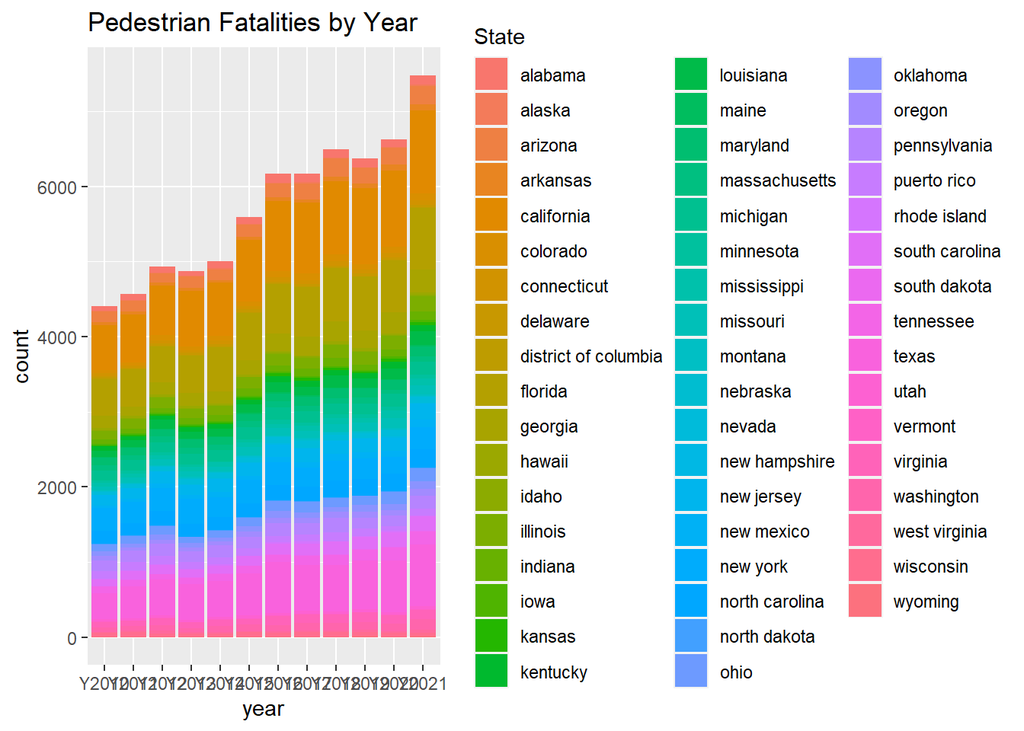

```r
# Aadhi

# Initializing stuff
state_map <- map_data("state")

colnames(state_map)[5] <- "State"   # making join easier

states_year <- states %>%        # Organizing by year and the count a numeric to plot
  pivot_longer(cols = Y2010:Y2021,
               names_to = "year",
               values_to = "count") %>%
  mutate(`count` = as.numeric(`count`))

temp_states <- left_join(state_map, states_year, by = "State") # making df to plot
# Pedestrian Fatalities by Year
states_year %>%
  filter(FatalityType == "Pedestrian Fatalities") %>%
  ggplot(aes(x = year, y = count, fill = State)) +
  geom_col() +
  ggtitle("Pedestrian Fatalities by Year")
```

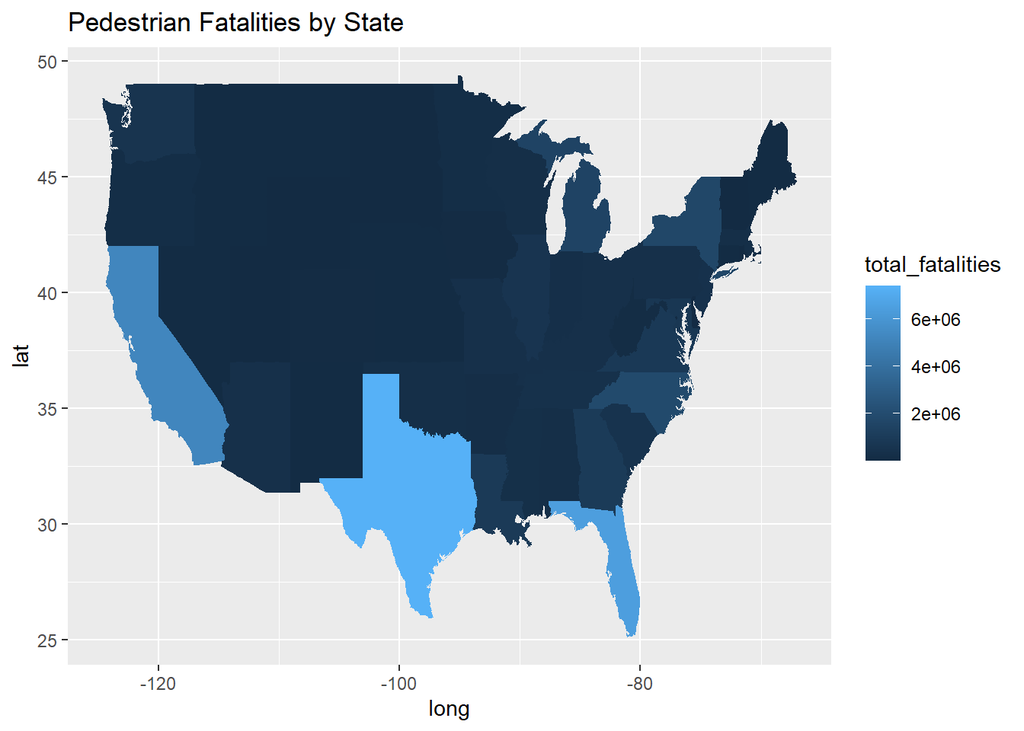

```r
# Pedestrian Fatalities by State
temp_states %>%
  filter(FatalityType == "Pedestrian Fatalities") %>%
  mutate(total_fatalities = sum(count), .by = State) %>%
  ggplot(aes(x = long, y = lat)) +
  geom_polygon(aes(group = group, fill = total_fatalities)) +
  ggtitle("Pedestrian Fatalities by State")
```

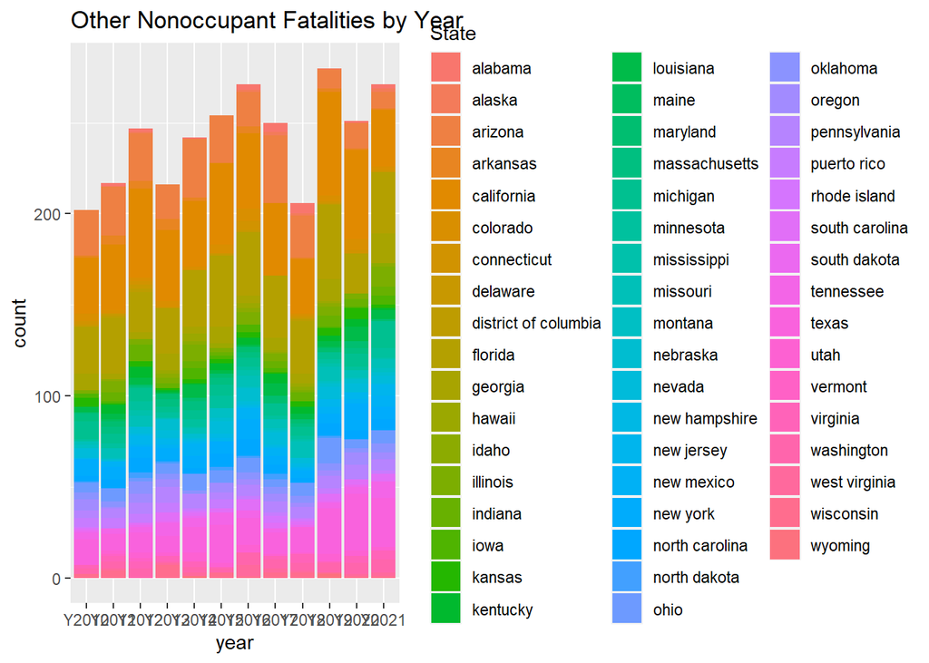

```r
# Other Nonoccupant Fatalities by Year
states_year %>%
  filter(FatalityType == "Other Nonoccupant Fatalities") %>%
  ggplot(aes(x = year, y = count, fill = State)) +
  geom_col() +
  ggtitle("Other Nonoccupant Fatalities by Year")
```

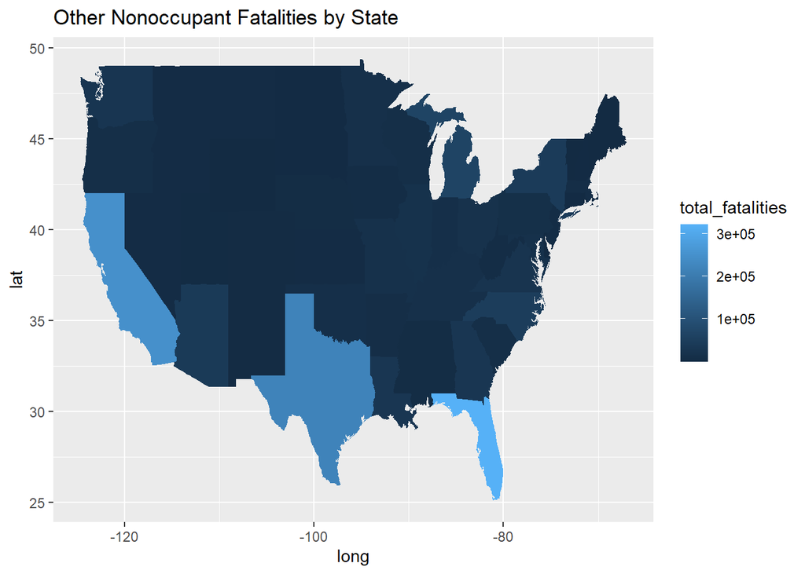

```r
# Other Nonoccupant Fatalities by State
temp_states %>%
  filter(FatalityType == "Other Nonoccupant Fatalities") %>%
  mutate(total_fatalities = sum(count), .by = State) %>%
  ggplot(aes(x = long, y = lat)) +
  geom_polygon(aes(group = group, fill = total_fatalities)) +
  ggtitle("Other Nonoccupant Fatalities by State")
```

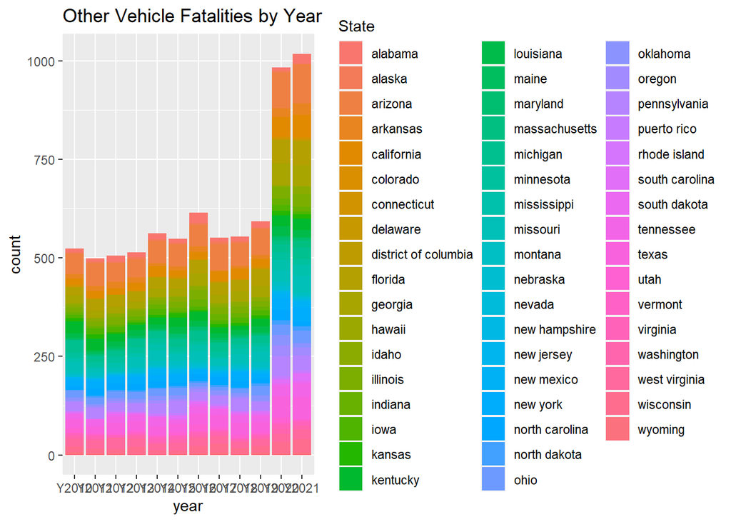

```r
# Other Vehicle Fatalities by Year
states_year %>%
  filter(FatalityType == "Other Vehicle Fatalities") %>%
  ggplot(aes(x = year, y = count, fill = State)) +
  geom_col() +
  ggtitle("Other Vehicle Fatalities by Year")
```

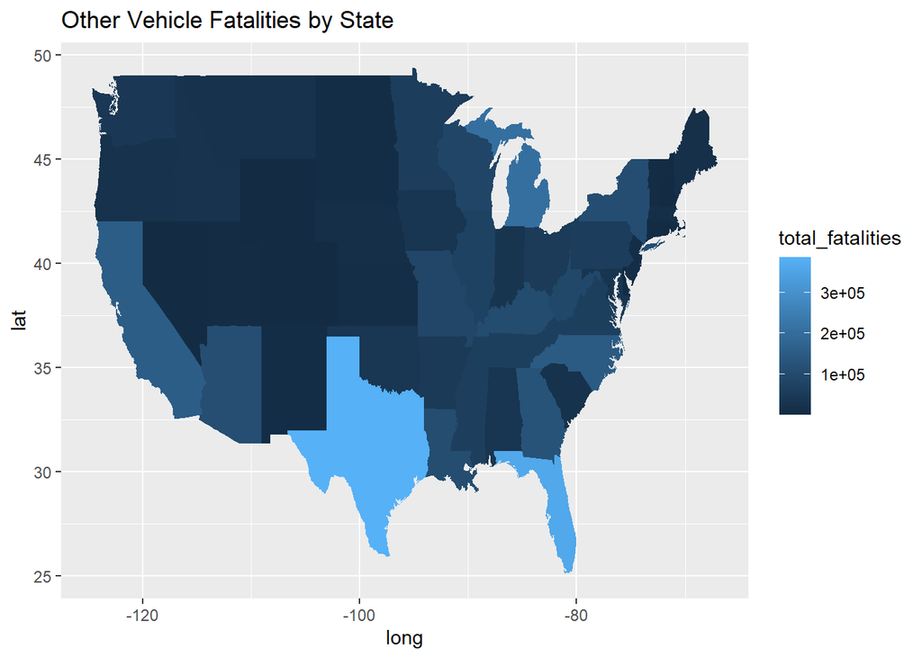

```r
# Other Vehicle Fatalities by State
temp_states %>%
  filter(FatalityType == "Other Vehicle Fatalities") %>%
  mutate(total_fatalities = sum(count), .by = State) %>%
  ggplot(aes(x = long, y = lat)) +
  geom_polygon(aes(group = group, fill = total_fatalities)) +
  ggtitle("Other Vehicle Fatalities by State")
```

```r
temp_states <- left_join(state_map, states_year, by = "State")
```

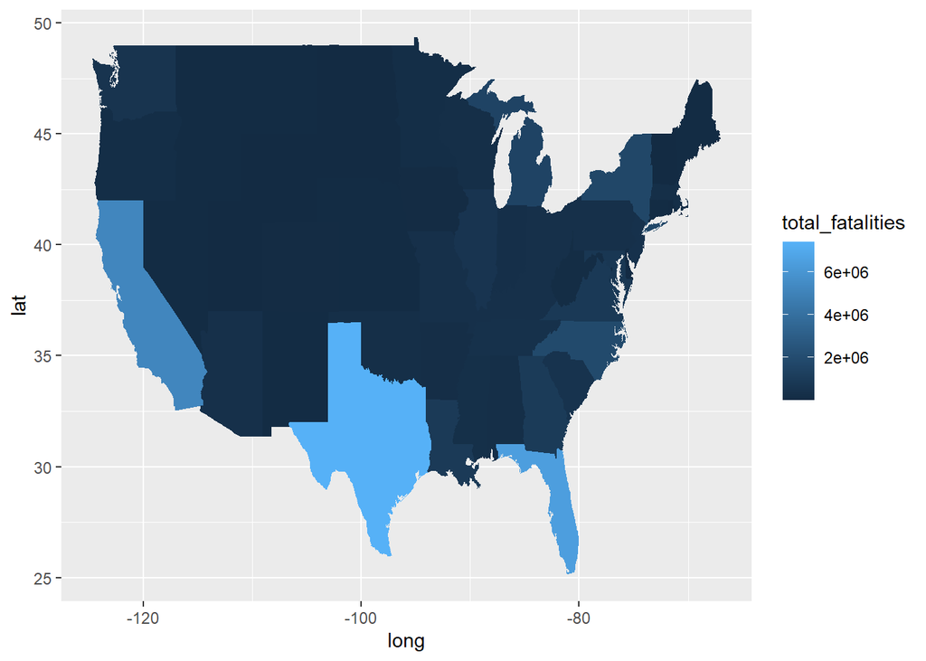

```r
temp_states %>%
  filter(FatalityType == "Pedestrian Fatalities") %>%
  mutate(total_fatalities = sum(count), .by = State) %>%
  ggplot(aes(x = long, y = lat)) +
  geom_polygon(aes(group = group, fill = total_fatalities))
```

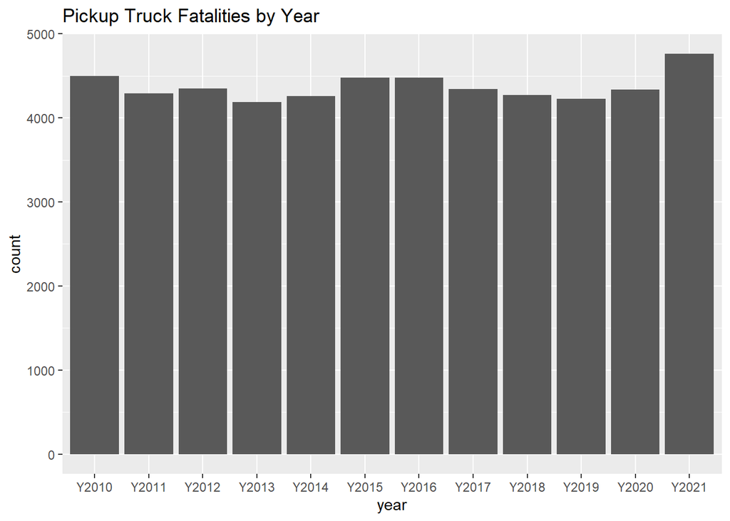

```r
# Conor

# Pickup Truck Fatalities by Year (Conor)

states_year %>%
  filter(FatalityType == "Pickup Truck Fatalities") %>%
  ggplot(aes(x = year, y = count)) +
  geom_col() +
  ggtitle("Pickup Truck Fatalities by Year")
```

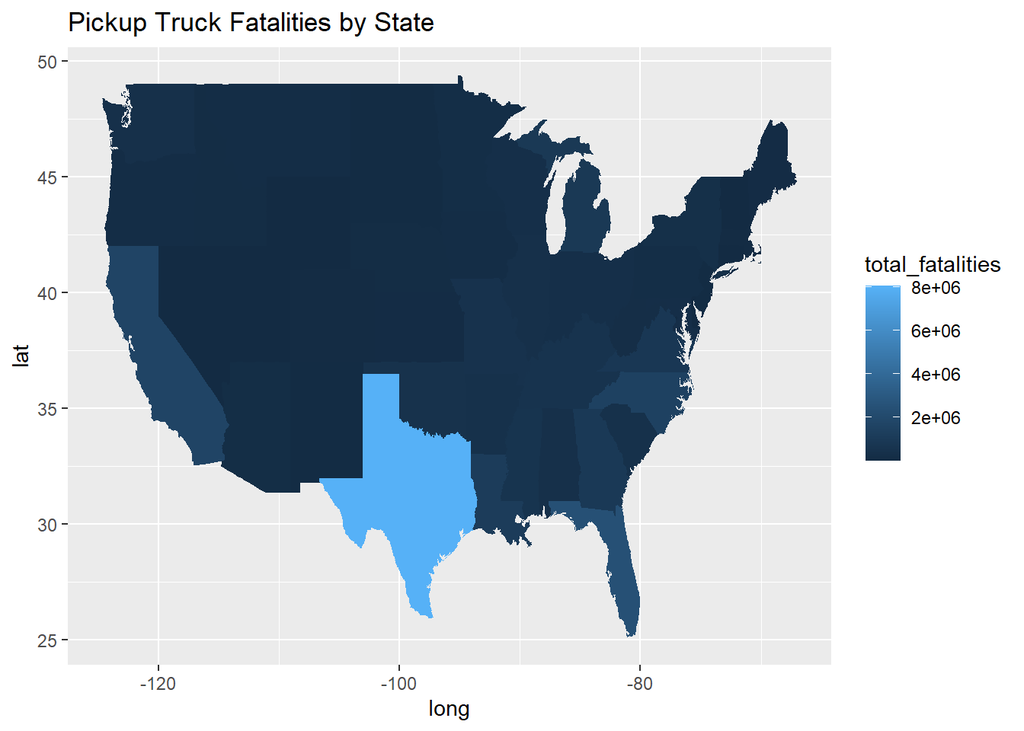

```r
# Pickup Truck Fatalities by State (Conor)

temp_states %>%
  filter(FatalityType == "Pickup Truck Fatalities") %>%
  mutate(total_fatalities = sum(count), .by = State) %>%
  ggplot(aes(x = long, y = lat)) +
  geom_polygon(aes(group = group, fill = total_fatalities)) +
  ggtitle("Pickup Truck Fatalities by State")
```

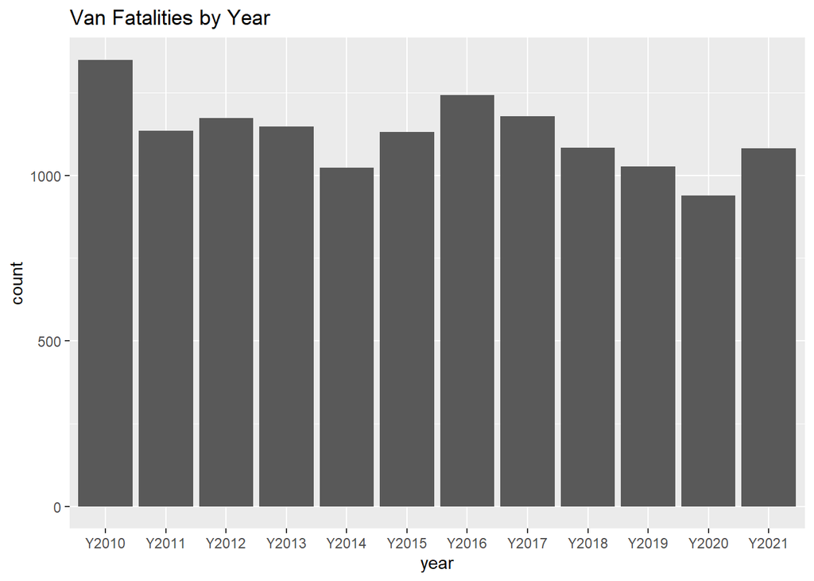

```r
# Van Fatalities by Year (Conor)

states_year %>%
  filter(FatalityType == "Van Fatalities") %>%
  ggplot(aes(x = year, y = count)) +
  geom_col() +
  ggtitle("Van Fatalities by Year")
```

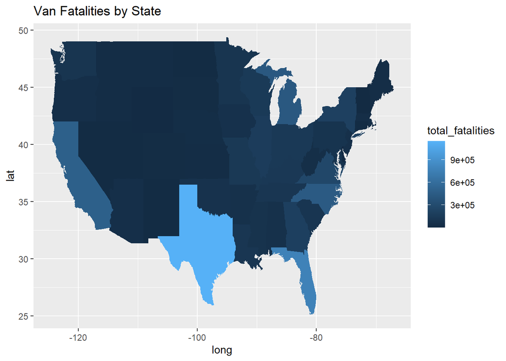

```r
# Van Fatalities by State (Conor)

temp_states %>%
  filter(FatalityType == "Van Fatalities") %>%
  mutate(total_fatalities = sum(count), .by = State) %>%
  ggplot(aes(x = long, y = lat)) +
  geom_polygon(aes(group = group, fill = total_fatalities)) +
  ggtitle("Van Fatalities by State")
```

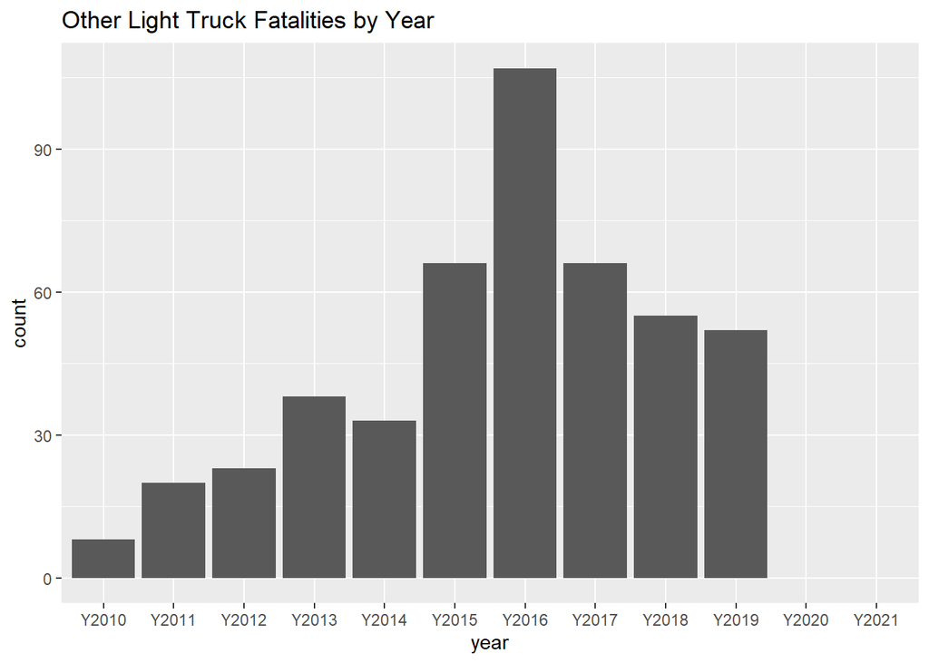

```r
# Other Light Truck Fatalities by Year (Conor)

states_year %>%
  filter(FatalityType == "Other Light Truck Fatalities") %>%
  ggplot(aes(x = year, y = count)) +
  geom_col() +
  ggtitle("Other Light Truck Fatalities by Year")
```

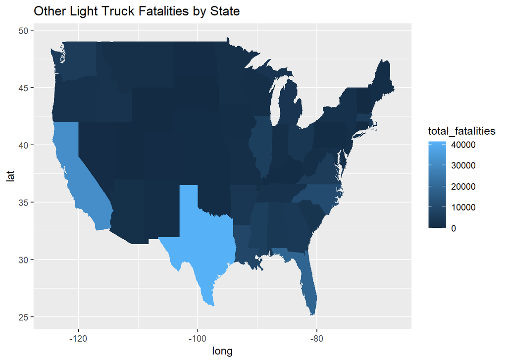

```r
# Other Light Truck Fatalities by State (Conor)

temp_states %>%
  filter(FatalityType == "Other Light Truck Fatalities") %>%
  mutate(total_fatalities = sum(count), .by = State) %>%
  ggplot(aes(x = long, y = lat)) +
  geom_polygon(aes(group = group, fill = total_fatalities)) +
  ggtitle("Other Light Truck Fatalities by State")
```

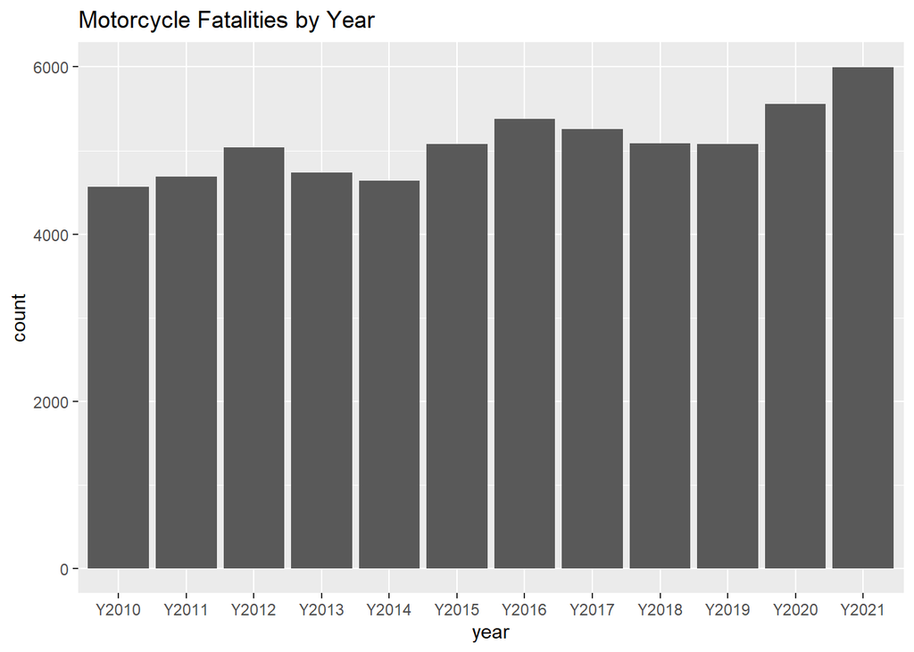

```r
# Motorcycle Fatalities by Year (Conor)

states_year %>%
  filter(FatalityType == "Motorcycle Fatalities") %>%
  ggplot(aes(x = year, y = count)) +
  geom_col() +
  ggtitle("Motorcycle Fatalities by Year")
```

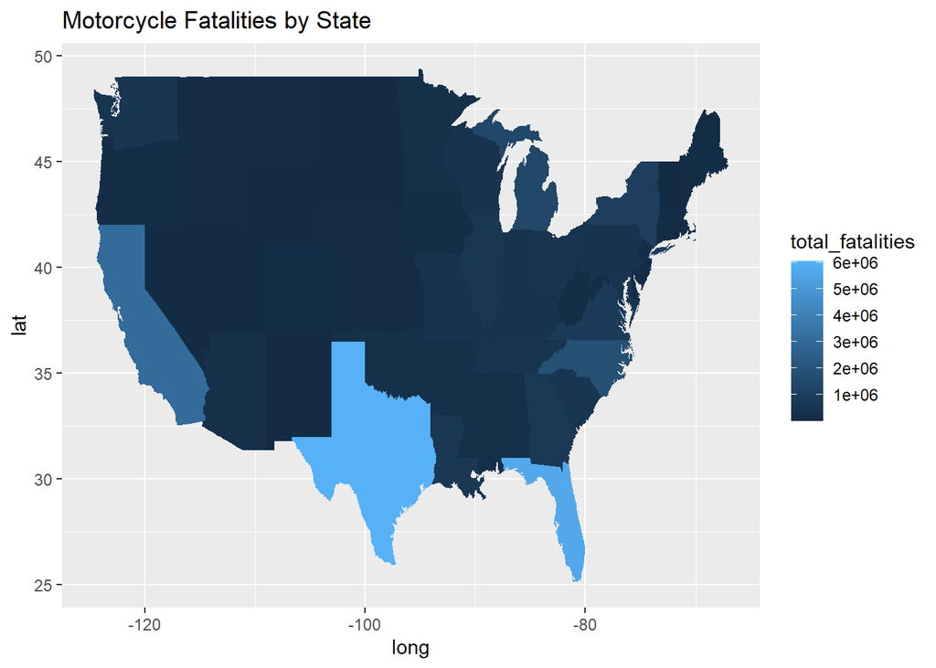

```r
# Motorcycle Fatalities by State (Conor)

temp_states %>%
  filter(FatalityType == "Motorcycle Fatalities") %>%
  mutate(total_fatalities = sum(count), .by = State) %>%
  ggplot(aes(x = long, y = lat)) +
  geom_polygon(aes(group = group, fill = total_fatalities)) +
  ggtitle("Motorcycle Fatalities by State")
```

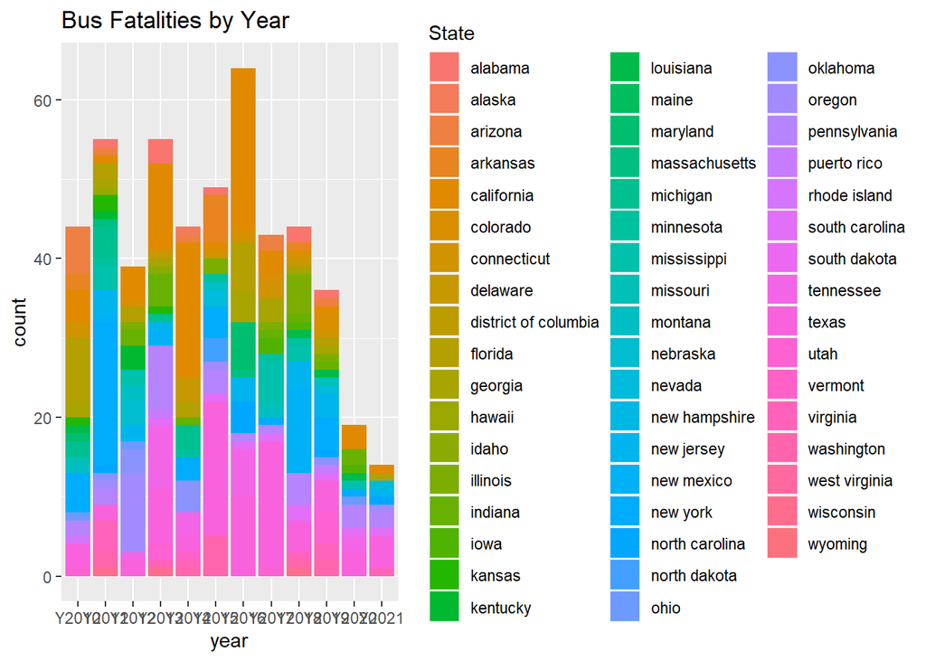

```r
# Daniel

# Bus Fatalities by year per state
states_year %>%
  filter(FatalityType == "Bus Fatalities") %>%
  ggplot(aes(x = year, y = count, fill = State)) +
  geom_col(space=1) +
  ggtitle("Bus Fatalities by Year")
```

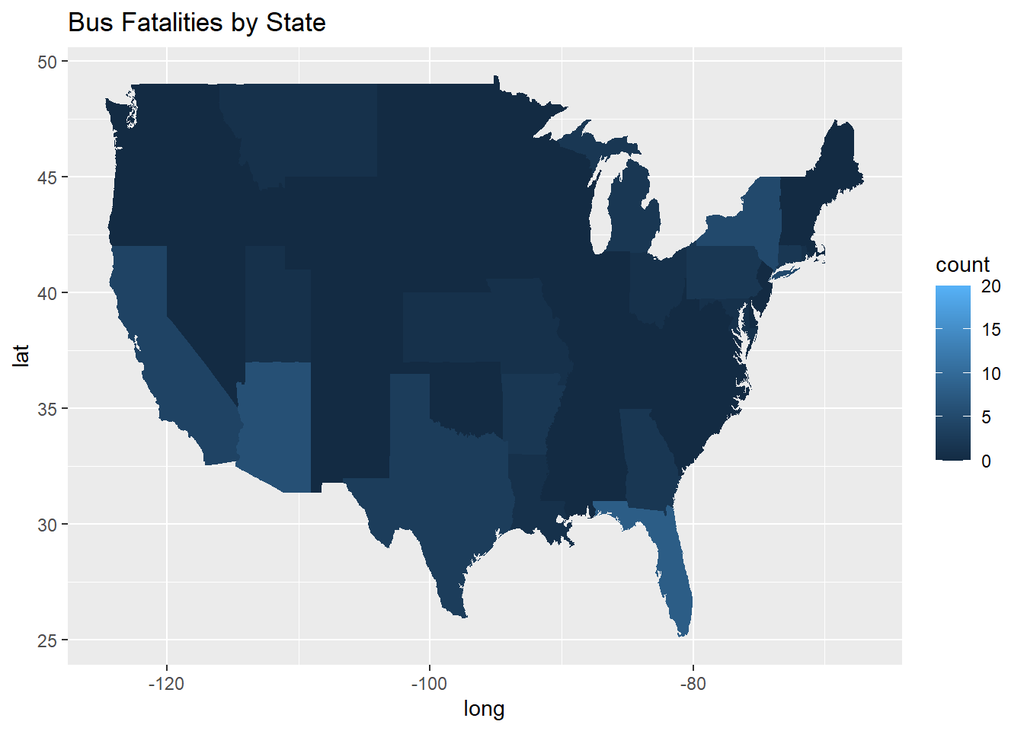

```r
temp_states %>%
  filter(FatalityType == "Bus Fatalities") %>%
  mutate(total_fatalities = sum(count), .by = State) %>%
  ggplot(aes(x = long, y = lat)) +
  geom_polygon(aes(group = group, fill = count)) +
  ggtitle("Bus Fatalities by State")
```

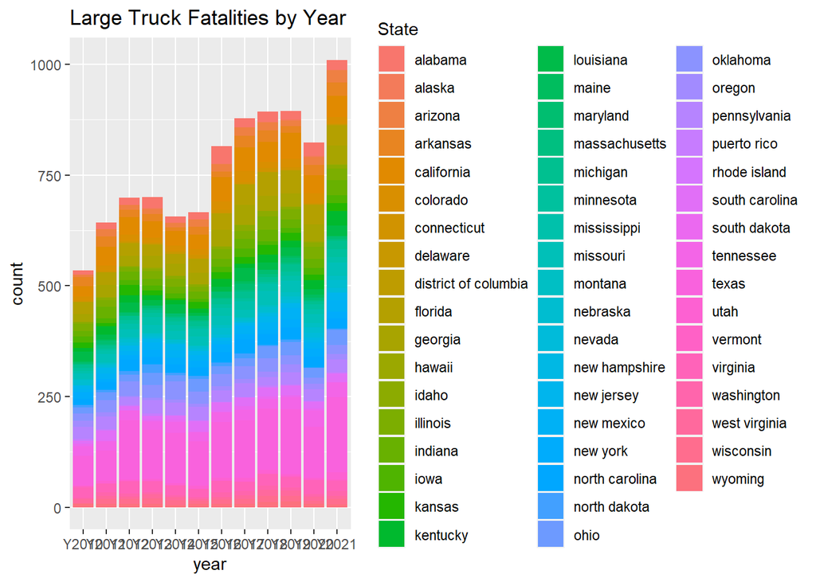

```r
# Large Truck Fatalities by year per state
states_year %>%
  filter(FatalityType == "Large Truck Fatalities") %>%
  ggplot(aes(x = year, y = count, fill = State)) +
  geom_col(space=1) +
  ggtitle("Large Truck Fatalities by Year")
```

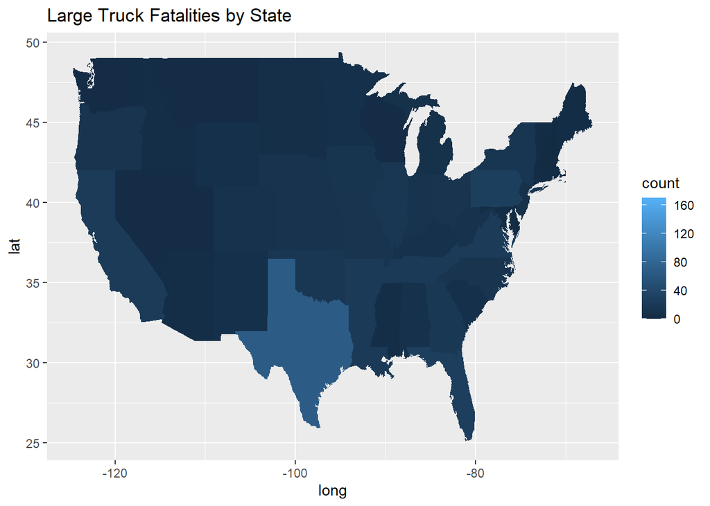

```r
temp_states %>%
  filter(FatalityType == "Large Truck Fatalities") %>%
  mutate(total_fatalities = sum(count), .by = State) %>%
  ggplot(aes(x = long, y = lat)) +
  geom_polygon(aes(group = group, fill = count)) +
  ggtitle("Large Truck Fatalities by State")
```

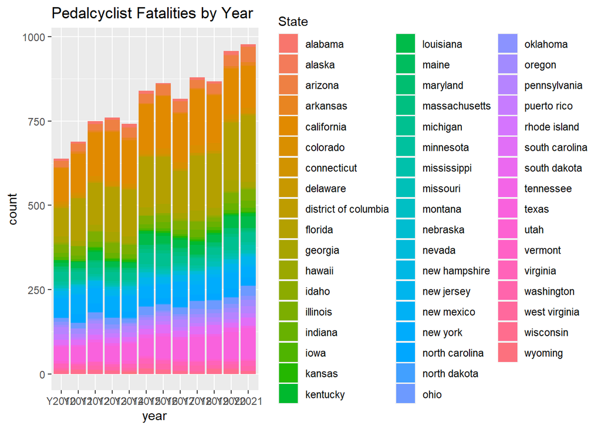

```r
# Pedalcyclist Fatalities by year per state
states_year %>%
  filter(FatalityType == "Pedalcyclist Fatalities") %>%
  ggplot(aes(x = year, y = count, fill = State)) +
  geom_col(space=1) +
  ggtitle("Pedalcyclist Fatalities by Year")
```

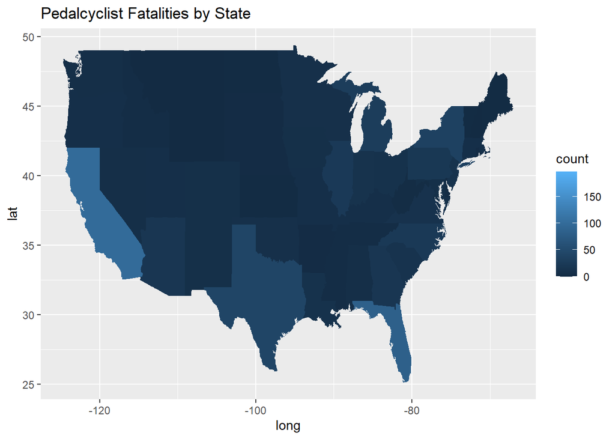

```r
temp_states %>%
  filter(FatalityType == "Pedalcyclist Fatalities") %>%
  mutate(total_fatalities = sum(count), .by = State) %>%
  ggplot(aes(x = long, y = lat)) +
  geom_polygon(aes(group = group, fill = count)) +
  ggtitle("Pedalcyclist Fatalities by State")
```

```r
# Roba

## Construct map of fatalality by state

states$region <- tolower(states$State)
state_map2 <- map_data("state")
state_map2 <- states %>% left_join(state_map2, by="region")
head(state_map2)
```

```
##     State       FatalityType Y2010 Y2011 Y2012 Y2013 Y2014 Y2015 Y2016 Y2017
## 1 alabama Highway Fatalities   862   895   865   853   820   850  1083   948
## 2 alabama Highway Fatalities   862   895   865   853   820   850  1083   948
## 3 alabama Highway Fatalities   862   895   865   853   820   850  1083   948
## 4 alabama Highway Fatalities   862   895   865   853   820   850  1083   948
## 5 alabama Highway Fatalities   862   895   865   853   820   850  1083   948
## 6 alabama Highway Fatalities   862   895   865   853   820   850  1083   948
##   Y2018 Y2019 Y2020 Y2021  region      long      lat group order subregion
## 1   953   930   934   983 alabama -87.46201 30.38968     1     1      <NA>
## 2   953   930   934   983 alabama -87.48493 30.37249     1     2      <NA>
## 3   953   930   934   983 alabama -87.52503 30.37249     1     3      <NA>
## 4   953   930   934   983 alabama -87.53076 30.33239     1     4      <NA>
## 5   953   930   934   983 alabama -87.57087 30.32665     1     5      <NA>
## 6   953   930   934   983 alabama -87.58806 30.32665     1     6      <NA>
```

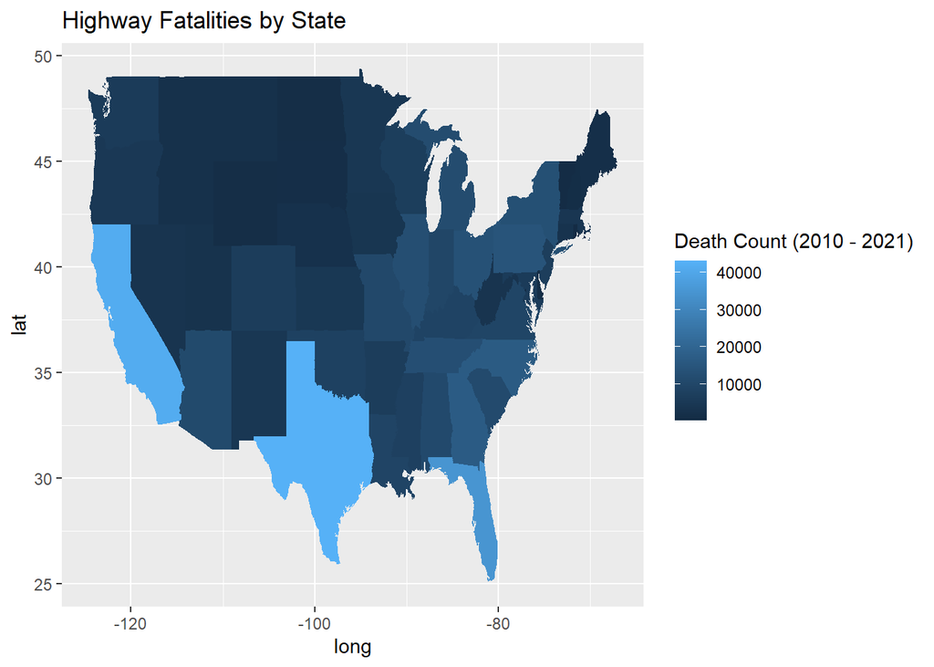

```r
state_map2 %>% filter(FatalityType == "Highway Fatalities") %>%
    ggplot(aes(x = long, y = lat,
    fill=Y2010+Y2011+Y2012+Y2013+Y2014+Y2015+Y2016+Y2017+Y2018+Y2019+Y2020+Y2021)) +
    geom_polygon(aes(group=group)) +
    scale_fill_continuous(name = "Death Count (2010 - 2021)") +
    ggtitle("Highway Fatalities by State")
```

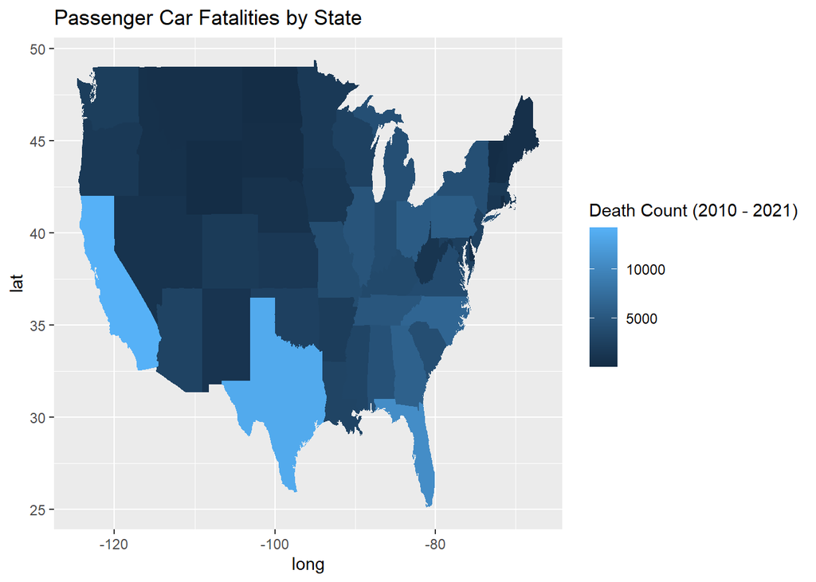

```r
state_map2 %>% filter(FatalityType == "Passenger Car Fatalities") %>%
    ggplot(aes(x = long, y = lat,
    fill=Y2010+Y2011+Y2012+Y2013+Y2014+Y2015+Y2016+Y2017+Y2018+Y2019+Y2020+Y2021)) +
    geom_polygon(aes(group=group)) +
    scale_fill_continuous(name = "Death Count (2010 - 2021)") +
    ggtitle("Passenger Car Fatalities by State")
```

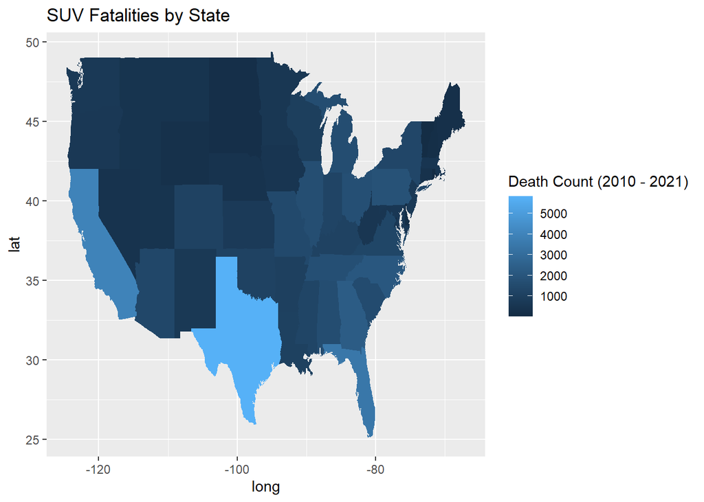

```r
state_map2 %>% filter(FatalityType == "SUV Fatalities") %>%
    ggplot(aes(x = long, y = lat,
    fill=Y2010+Y2011+Y2012+Y2013+Y2014+Y2015+Y2016+Y2017+Y2018+Y2019+Y2020+Y2021)) +
    geom_polygon(aes(group=group)) +
    scale_fill_continuous(name = "Death Count (2010 - 2021)") +
    ggtitle("SUV Fatalities by State")
```

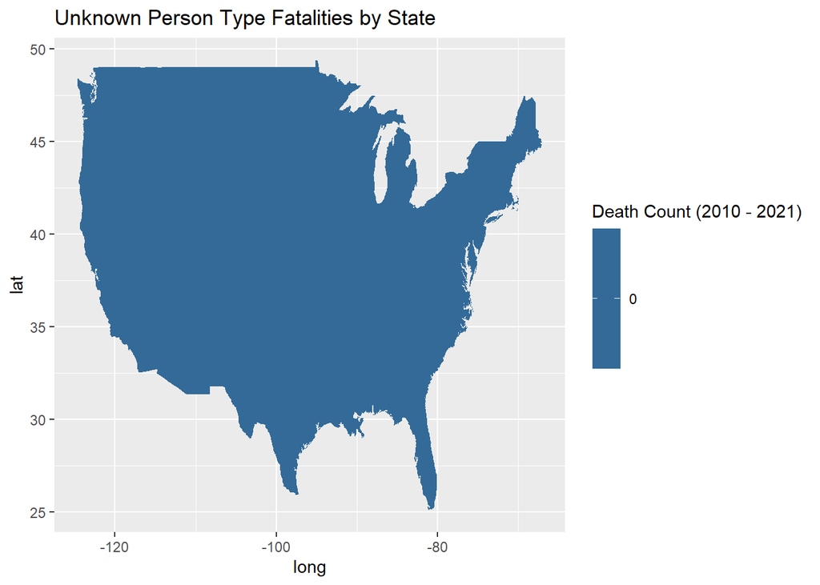

```r
state_map2 %>% filter(FatalityType == "Unknown Person Type Fatalities") %>%
    ggplot(aes(x = long, y = lat,
    fill=Y2010+Y2011+Y2012+Y2013+Y2014+Y2015+Y2016+Y2017+Y2018+Y2019+Y2020+Y2021)) +
    geom_polygon(aes(group=group)) +
    scale_fill_continuous(name = "Death Count (2010 - 2021)") +
    ggtitle("Unknown Person Type Fatalities by State")
```

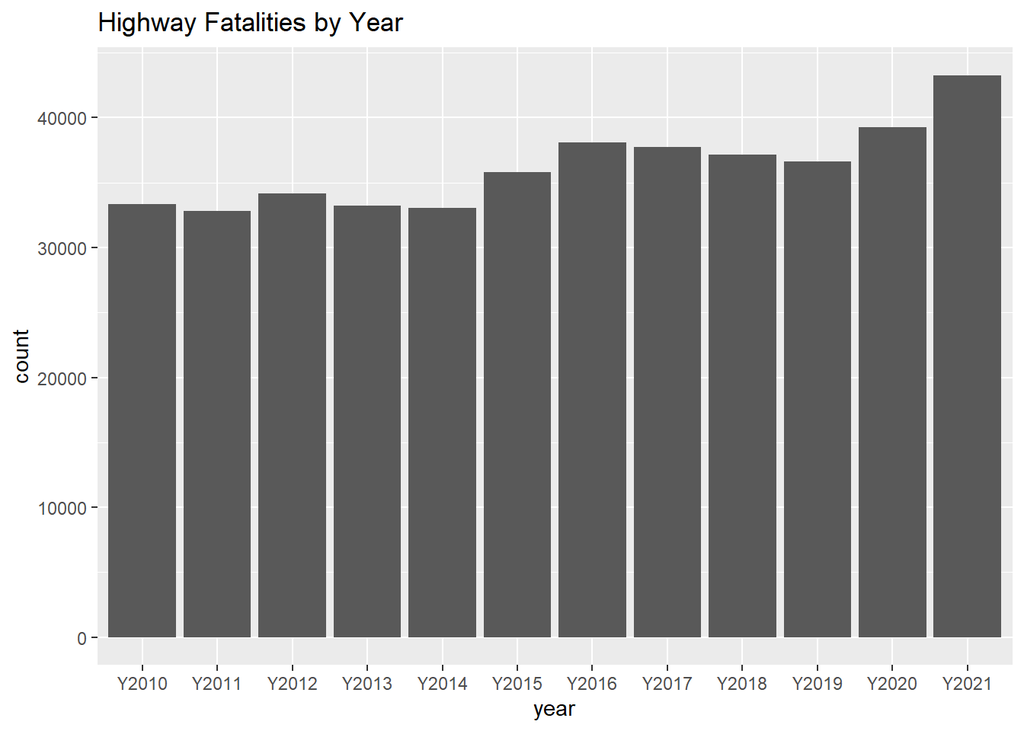

```r
## Construct map of fatalality by year

state_map_year <- states %>%
  pivot_longer(cols = Y2010:Y2021,
               names_to = "year",
               values_to = "count") %>%
  mutate(`count` = as.numeric(`count`))

state_map_year %>%
  filter(FatalityType == "Highway Fatalities") %>%
  ggplot(aes(x = year, y = count)) +
  geom_col() +
  ggtitle("Highway Fatalities by Year")
```

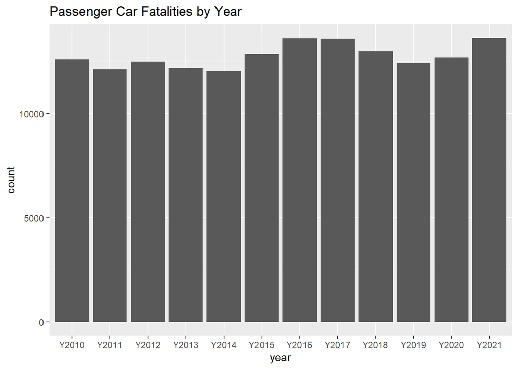

```r
state_map_year %>%
  filter(FatalityType == "Passenger Car Fatalities") %>%
  ggplot(aes(x = year, y = count)) +
  geom_col() +
  ggtitle("Passenger Car Fatalities by Year")
```

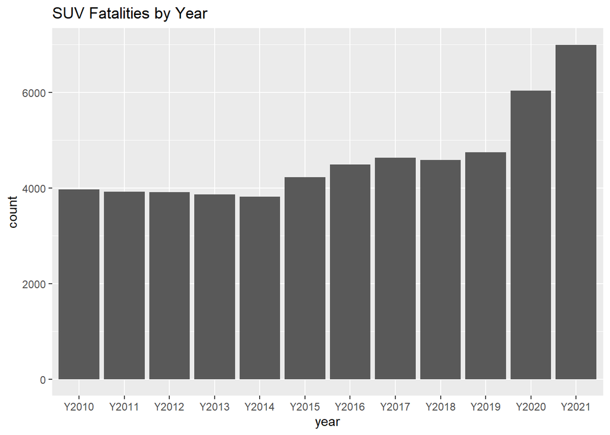

```r
state_map_year %>%
  filter(FatalityType == "SUV Fatalities") %>%
  ggplot(aes(x = year, y = count)) +
  geom_col() +
  ggtitle("SUV Fatalities by Year")
```

[figure not shown]

```r
state_map_year %>%
  filter(FatalityType == "Unknown Person Type Fatalities") %>%
  ggplot(aes(x = year, y = count)) +
  geom_col() +
  ggtitle("Unknown Person Type Fatalities by Year")
```